Review

Opioid-Sparing Effect of Cannabinoids: A Systematic Review

and Meta-Analysis

Suzanne Nielsen*<sup>,1,2</sup>, Pamela Sabioni<sup>3</sup>, Jose M Trigo<sup>3</sup>, Mark A Ware<sup>4</sup>, Brigid D Betz-Stablein<sup>5</sup>,

Bridin Murnion<sup>6,7</sup>, Nicholas Lintzeris<sup>2,6</sup>, Kok Eng Khor<sup>8</sup>, Michael Farrell<sup>1</sup>, Andrew Smith<sup>9</sup>and Bernard Le Foll<sup>3</sup>

1The National Drug and Alcohol Research Centre, The University of New South Wales, Sydney, NSW, Australia; 2Drug and Alcohol Services, South

Eastern Sydney Local Health District, Surry Hills, NSW, Australia; <sup>3</sup>Translational Addiction Research Laboratory, Campbell Family Mental Health

Research Institute, Centre for Addiction and Mental Health, Toronto, ON, Canada; <sup>4</sup>Departments of Anaesthesia and Family Medicine, McGill

University, Montreal, QC, Canada; <sup>5</sup>School of Public Health and Community Medicine, The University of New South Wales, Sydney, NSW, Australia;

6Discipline of Addiction Medicine, University of Sydney, Sydney, NSW, Australia; 7Pain Management Centre, Royal Prince Alfred Hospital,

Camperdown, NSW, Australia; <sup>8</sup>Department of Pain Management, Prince of Wales Hospital, Randwick, NSW, Australia; <sup>9</sup>Pain and Addiction

Medicine, Centre for Addiction and Mental Health, Toronto, ON, Canada

Cannabinoids, when co-administered with opioids, may enable reduced opioid doses without loss of analgesic efficacy (ie, an opioid-

sparing effect). The aim of this study was to conduct a systematic review to determine the opioid-sparing potential of cannabinoids. Eligible

studies included pre-clinical and clinical studies for which the outcome was either analgesia or opioid dose requirements. Clinical studies

included controlled studies and case series. We searched Scopus, Cochrane Database of Systematic Reviews, Medline, and Embase.

Nineteen pre-clinical and nine clinical studies met the search criteria. Seventeen of the 19 pre-clinical studies provided evidence of

synergistic effects from opioid and cannabinoid co-administration. Our meta-analysis of pre-clinical studies indicated that the median

effective dose (ED50) of morphine administered in combination with delta-9-tetrahydrocannabinol (delta-9-THC) is 3.6 times lower

(95% confidence interval (CI) 1.95, 6.76; n = 6) than the ED50 of morphine alone. In addition, the ED50 for codeine administered in

combination with delta-9-THC was 9.5 times lower (95% CI 1.6, 57.5, n = 2) than the ED50 of codeine alone. One case series (n = 3)

provided very-low-quality evidence of a reduction in opioid requirements with cannabinoid co-administration. Larger controlled clinical

studies showed some clinical benefits of cannabinoids; however, opioid dose changes were rarely reported and mixed findings were

observed for analgesia. In summary, pre-clinical studies provide robust evidence of the opioid-sparing effect of cannabinoids, whereas one

of the nine clinical studies identified provided very-low-quality evidence of such an effect. Prospective high-quality-controlled clinical trials

are required to determine the opioid-sparing effect of cannabinoids.

Neuropsychopharmacology (2017) 42, 1752–1765; doi:10.1038/npp.2017.51; published online 5 April 2017

INTRODUCTION

Chronic pain is associated with enormous personal, social,

and economic burden and is the largest contributor to years

lived with disability globally (Rice et al, 2015). Despite this,

existing medications provide only modest relief. Opioids in

particular have considerable side effects, including constipa-

tion, impaired sleep, and respiratory depression (Chou et al,

2015). The last two decades have seen an increase in the

prescription of opioids, which has been associated with an

increase in opioid use disorders and opioid-related mortality

(Chou et al, 2015; Volkow and McLellan, 2016; Zedler et al,

2014). This has been termed as an ‘opioid crisis’, and has

caused regulators, health professionals, and the public to

begin seeking means to reduce problems associated with

high-dose opioid use. Consequently, there is a need for

evidence-based strategies for reducing reliance on high-dose

opioids without compromising pain management.

Using combinations of medications to harness comple-

mentary but distinct mechanisms of action can maximize the

analgesic response, enabling the use of a lower dose of each

medication and resulting in an improved side effect profile.

One promising area for medication combinations is the use

of opioid-sparing medications. Opioid-sparing medications,

when co-administered with opioids, enable a reduced opioid

dose

without

loss

of

analgesic

efficacy.

Cannabinoid

medications are increasingly being studied for their analge-

sic- and opioid-sparing potential. The endocannabinoid

system represents an ideal target because it is a key

endogenous system in modulating pain-processing pathways

(Woodhams et al, 2015).

The endocannabinoid system is composed of the canna-

binoid CB1 and CB2 receptors, the endocannabinoid ligands

*Correspondence: Dr S Nielsen, The National Drug and Alcohol

Research Centre, The University of New South Wales, Sydney, NSW

2052, Australia, Tel: +61 2 89361017, Fax: +61 2 9385 0222,

E-mail: suzanne.nielsen@unsw.edu.au

Received 11 July 2016; revised 31 January 2017; accepted 7 March

2017; accepted article preview online 22 March 2017

anandamide and 2-arachidonoylglycerol, and their synthesis

and degradation system (Pertwee, 2006). CB1 and CB2

receptors are differentially expressed on the central nervous

system (Cencioni et al, 2010; Herkenham et al, 1991) and

play important roles in pain processes. Both cannabinoid

receptors and endocannabinoids are present in the primary

afferent pain circuits to the brain (Manzanares et al, 1999;

Woodhams et al, 2015). Cannabinoid and opioid receptors

have similar signal transduction systems (Cichewicz, 2004;

Howlett et al, 2002; Vigano et al, 2005) and are expressed in

several brain regions involved in antinociception, including

the periaqueductal gray, raphe nuclei, and central-medial

thalamic nuclei (Cichewicz, 2004). In addition, mu-opioid

receptors and CB1 receptors co-localize in the spinal cord at

the first synaptic contact for peripheral nociceptive afferent

neurons (Hohmann et al, 1999; Salio et al, 2001).

It has previously been observed that CB2 receptors

indirectly stimulate opioid receptors located in primary

afferent pathways (Ibrahim et al, 2005). Therefore, in

addition to their direct analgesic effects, cannabinoids may

work synergistically to enhance opioid analgesia. The

behavioral, anatomical, and biochemical similarities between

opioid and cannabinoid receptor systems and their endo-

genous ligands are well documented. For example, activation

of either cannabinoid or opioid receptors produces compar-

able neurobehavioral and physiological effects, including

antinociception (Manzanares et al, 1999). This is highlighted

by both CB1 and CB2 agonists being able to induce

antinociception

by

increasing

opioid

precursors’

gene

expression or via release of endogenous opioids (Houser

et al, 2000; Ibrahim et al, 2005; Valverde et al, 2001). Further,

pharmacological modulation of the opioid system can

modify the effects of delta-9-tetrahydrocannabinol (delta-9-

THC)—a partial agonist at the CB1 and CB2 receptor—on

nociception (Mason et al, 1999; Pugh et al, 1997; Smith et al,

1994) and vice versa. Finally, cannabinoid antagonists have

been shown to reverse the antinociception induced by

morphine (da Fonseca Pacheco et al, 2008). Collectively,

this strongly supports shared mechanisms between both

systems in regard to analgesia.

Animal models have identified a role for CB1 receptor

activation in reducing neuropathic, visceral, and inflamma-

tory pain (Pertwee, 2008; Walker et al, 1999). Several pre-

clinical studies have demonstrated that systemic administra-

tion of cannabinoid receptor ligands produces analgesia in

acute and chronic pain models (Walker and Huang, 2002).

In addition, the role of CB2 receptors has been explored in

pre-clinical studies, suggesting that these receptors may

mediate effects in inflammatory pain states (Ibrahim et al,

2006; Quartilho et al, 2003), and reduce inflammation and

neuropathic pain (Gui et al, 2015).

Further to these pre-clinical findings, clinical studies

indicate that cannabinoid administration may reduce pain

and improve other symptoms such as sleep disturbances

associated with chronic pain (Ware et al, 2010a; Ware et al,

2010b). This effect could be mediated by delta-9-THC, which

is the main psychoactive ingredient present in cannabis

(Cichewicz, 2004; Jensen et al, 2015). Despite the growing

body of relevant literature, to date no systematic review has

focused on the opioid-sparing effects of cannabinoids. To

address this gap, we conducted a systematic review of pre-

clinical and clinical studies to examine the strength of

existing evidence demonstrating the opioid-sparing effect of

cannabinoids in the context of analgesia.

MATERIALS AND METHODS

Search

We conducted a systematic search of the literature in

accordance with recommendations by the Preferred Report-

ing

Items

for

Systematic

Reviews

and

Meta-Analyses

(PRISMA) (Moher et al, 2009). The search aimed to identify

clinical and pre-clinical studies using the following electronic

databases: Scopus, Cochrane Database of Systematic Re-

views, Medline, and Embase. Search terms are listed and a

sample

search

strategy

is

reported

in

Supplementary

Appendix 1. No date limits were included. Searches were

run on 29 October 2015. In addition, reference lists from

identified studies and review articles were searched to find

additional studies not identified by the main search.

Eligible studies included:

� Human or animal studies.

� Outcomes of either pain/analgesia or opioid requirements/

opioid-sparing effects from concurrently administered

opioids and cannabinoids.

� Controlled clinical studies and case series.

Titles were screened by two authors (SN and PS). Where

inconsistencies were identified, the authors were able to

reach consensus on each occasion.

Data Extraction and Outcomes

Data extraction forms were developed and circulated to the

author group before piloting and refining. All data were

extracted by one of the authors (SN, PS, or JMT) and

checked by a second author (SN, PS, or JMT). These same

authors reviewed and resolved any inconsistencies, with

input from the authorship group as required. When required

data were missing, attempts were made to contact authors of

published reports to collect additional information.

Outcome Measures

For pre-clinical studies, the primary outcome was the dose of

opioid required to give an equivalent antinociceptive effect in

the presence and absence of cannabinoids. For clinical

studies, the primary outcome was evidence of the opioid-

sparing effect of cannabinoids. Data were extracted on opioid

dose and/or analgesic outcome where cannabinoids were

co-administered. Secondary outcome measures examined

included analgesia, sleep, and quality of life.

Analysis

Pre-clinical studies.

Data were extracted and a narrative

review was conducted. Ten studies were identified as

sufficiently similar in design and outcome measures to be

eligible for meta-analysis. Of these, six reported sufficient

data to enable meta-analysis; that is, the dose of opioid

required to produce comparable analgesia in the presence

and absence of cannabinoids, the variance of the observed

dose, and the sample size. Authors of the other studies were

contacted in an attempt to include additional studies in the

meta-analysis; however, no additional data were identified to

enable the inclusion of any additional studies.

To prepare the data for the meta-analysis, the effective

dose (ED50) and either confidence limits or SE were

extracted from the relevant literature. ED50 is calculated on

the log10 scale. Therefore, to meet the assumption of

normality, the log 10 <sup>c</sup>

ED50 must be used in the meta-

analysis. The log10 of the confidence limits must also be

determined to calculate the SD of the log 10 <sup>c</sup>

ED50:

SD log 10 <sup>c</sup>

ED50

�

�

ED50

1:96

;

where UL is the upper confidence limit.

When only SE was reported, the confidence limits were

calculated using the method of Litchfield and Wilcoxon

(1949) and the above procedure was repeated to calculate

the SD. This method also allowed for the inclusion of studies

that did not report exact sample sizes for all treatment

groups, as sample size was not required for the calculation

of SD.

Data for the meta-analysis were analyzed using Review

Manager 5.1 (Cochrane Collaboration, Oxford, UK). When

calculating the continuous outcome of an equally effective

opioid dose (eg, the log10ED50 for morphine when adminis-

tered alone vs when administered with a cannabinoid), the

inverse variance statistical method and random effects model

were used to compensate for study heterogeneity.

No statistical difference was found in outcomes between

the studies that used different species or nociceptive assays.

Therefore, the mean difference of log 10ED50 of and the

corresponding 95% confidence intervals (CI) were calcu-

lated. Due to the nature of log calculations, the mean

difference—when back-transformed to the original units—

represents the response ratio. For easier interpretation, we

present the reciprocal of the response rate.

Assessment of bias in pre-clinical studies.

A funnel plot

was produced to examine publication bias and small study

effects in the pre-clinical studies included in the meta-

analysis.

Clinical studies.

The nine clinical studies identified were

heterogeneous in design and outcomes, and therefore

not suitable for meta-analysis. Thus, a narrative synthesis

was conducted instead, with all studies scored for quality

using the Grading of Recommendations Assessment, Devel-

opment and Evaluation (GRADE) criteria (Guyatt et al,

2008).

RESULTS

The initial searches identified 3019 records after duplicates

were removed, with 19 pre-clinical and nine clinical studies

identified for inclusion in the final review (see Figure 1 for

the PRISMA diagram).

[figure not shown]

Records identified through database

searching

(n = 3245)

Screening

Included

Eligibility

Identification

Additional records identified

through other sources

(n = 3)

Records after duplicates removed

(n = 3019)

Records screened (SN+PS)

(n = 3019)

Records excluded

(n = 2973)

Full-text articles assessed for

eligibility (SN + PS)

(n = 46)

Full-text articles excluded,

(n = 18; wrong study

design, opioid doses not

reported, cannabinoids not

administered concurrently,

no data on analgesic

outcomes)

Studies included in qualitative

synthesis

(n = 28)

Studies included in quantitative

synthesis (meta-analysis) of

preclinical data for morphine

(n = 6)

Studies included in quantitative

synthesis (meta-analysis) of

preclinical data for codeine

(n = 2)

Figure 1

PRISMA diagram showing study identification. PRISMA, Preferred Reporting Items for Systematic Reviews and Meta-Analyses.

Table 1 Summary of Evidence of Opioid-Sparing Effects from Pre-Clinical Studies

Equipotent opioid dose represented as ED50(95% CL) or ± SEM, unless measured otherwise specified

Study

reference

Pain model (species)

Opioid administered

Cannabinoid

administered

Cannabinoid condition

Vehicle condition

Potency ratio or evidence of

synergism

Other notes

Cichewicz et al,

1999

Tail-flick test

(male ICR mice)

Morphine p.o.

Delta-9-THC (20 mg/kg p.o.)

13.1 mg/kg (8.8, 19.5)

28.8 mg/kg (20.2, 41)

Potency ratio: 2.2

Codeine p.o.

Delta-9-THC (20 mg/kg p.o.)

5.9 mg/kg (1.4, 24.9)

139.9 mg/kg (75.2, 260.5)

Potency ratio: 25.8

Oxymorphone p.o.

Delta-9-THC (20 mg/kg p.o.)

0.5 mg/kg (0.3, 0.8)

2.6 mg/kg (1.7, 3.9)

Potency ratio: 5.0

Hydromorphone p.o.

Delta-9-THC (20 mg/kg p.o.)

0.4 mg/kg (0.2, 0.8)

5.6 mg/kg (3.2, 9.7)

Potency ratio: 12.6

Methadone p.o.

Delta-9-THC (20 mg/kg p.o.)

2.7 mg/kg (1.4, 5.2)

12.0 mg/kg (8.1, 17.9)

Potency ratio: 4.1

LAAM p.o.

Delta-9-THC (20 mg/kg p.o.)

2.6 mg/kg (1.7, 3.9)

8.0 mg/kg (6.4, 10.1)

Potency ratio: 2.5

Heroin p.o.

Delta-9-THC (20 mg/kg p.o.)

5.4 mg/kg (1.7, 16.9)

26.1 mg/kg (12.7, 53.4)

Potency ratio: 4.1

Meperidine p.o.

Delta-9-THC (20 mg/kg p.o.)

11.1 mg/kg (4.2, 29.4)

86.2 mg/kg (52.8, 140.6)

Potency ratio: 8.9

Fentanyl p.o.

Delta-9-THC (20 mg/kg p.o.)

0.5 mg/kg (0.3, 0.8)

6.1 mg/kg (estimated from an

extrapolated curve)

Not determined (50% MPE not

seen)

Pentazocine p.o.

Delta-9-THC (20 mg/kg p.o.)

838.6 mg/kg (estimated

from an extrapolated curve)

625.9 mg/kg (estimated from

an extrapolated curve)

Not determined (50% MPE not

seen)

Cichewicz and

Welch, 2003

Tail-flick test

(male ICR mice)

Morphine p.o.

Codeine p.o.

Delta-9-THC (5–35 mg/kg

and 1–27 mg/kg p.o.)

Delta-9-THC (5–30 and

5–18 mg/kg p.o.)

13.6 mg/kg ± 1.94

20.1 mg/kg ± 3.0

24.5 mg/kg ± 4.8

78.2 mg/kg ± 14.4

For each ratio tested, experimental

values were less than the calculated

additive values (synergism)

For each ratio tested, experimental

values were less than the calculated

additive values (synergism)

Fixed-ratio combinations of 9-THC

with either morphine or codeine

were tested for antinociceptive

effects. The experimentally derived

ED50 for each combination was

compared with the theoretical

additive ED50, using an

isobolographic analysis. All the

fixed-ratio combinations tested

produced greater antinociception

(synergy) than predicted from

simple additivity

Cichewicz et al,

2005

Pin-prick test

(IAF hairless guinea pigs)

Fentanyl s.c.

Delta-9-THC (50 mg/kg i.p.)

6.8 μg/kg (3.3, 14.2)

50.8 μg/kg (41.0, 63.0)

Greater than additive effect on

antinociception. Potency ratio: 6.7

(1.8–17.0)

Buprenorphine s.c.

Delta-9-THC (50 mg/kg i.p.)

0.02 mg/kg (0.01, 0.05)

2.97 mg/kg (1.84, 4.81)

Greater than additive effect on

antinociception. Enhanced potency

in a non-parallel fashion

Not possible to compare the

change in potency produced by

delta-9-THC due to the non-

parallel nature of the two dose–

response curves for buprenorphine

Fentanyl t.d.

Delta-9-THC (400 mg/kg t.d.)

2 h: 254.9 μg/kg

(202.90, 320.6)

4 h: 176.3 μg/kg

(144.3, 215.5)

2 h: 928.6 μg/kg

(599.5, 1438.3)

4 h: 1067.0 μg/kg

(840.4, 1356.1)

Potency ratio at 2 h: 3.7

Potency ratio at 4 h: 5.8

Buprenorphine t.d.

Delta-9-THC (400 mg/kg t.d.)

2 h: 4.3 mg/kg (2.8, 6.8)

4 h: 2.2 mg/kg (1.1, 4.6)

2 h: 26.1 mg/kg (17.1, 39.9)

4 h: 15.6 mg/kg (10.0, 24.5)

Potency ratio at 2 h: 8.2

Potency ratio at 4 h: 7.2

Cox et al, 2007

Paw pressure test (Male

Sprague–Dawley rats)

Morphine i.p. (normal rats)

Morphine i.p. (arthritic rats)

Delta-9-THC

(0.4 mg/kg ± 0.5 i.p.)

(1 : 1 ratio THC : Morphine)

Delta-9-THC (0.6 mg/

kg ± 0.55 i.p.)

(1 : 1 ratio THC : Morphine)

0.4 mg/kg ± 0.5

0.6 mg/kg ± 0.55

2.4 mg/kg (2.2, 2.8)

2.2 mg/kg (1.9, 2.4).

The combination of delta-9-THC

and morphine showed synergism in

both non-arthritic and arthritic rats

Results from normal rats included in

the meta-analysis only

Finn et al, 2004

Formalin-evoked

nociceptive behavior

(adult male Lister-

Hooded rats)

Morphine i.p.

Delta-9-THC (1 mg/kg i.p.)

Not reported

Not reported

Not clearly synergistic. Potentially

additive. Morphine (2 mg/kg) +

delta-9-THC (1 mg/kg) had a

significant effect on nociceptive

behavior (compared to morphine

alone but not delta-9-THC alone).

Table 1 Continued

Equipotent opioid dose represented as ED50(95% CL) or ± SEM, unless measured otherwise specified

Study

reference

Pain model (species)

Opioid administered

Cannabinoid

administered

Cannabinoid condition

Vehicle condition

Potency ratio or evidence of

synergism

Other notes

Katsuyama

et al, 2013

Capsaicin test (Male mice

of ddY strain)

Morphine (1.0 mg/kg s.c. and

100 pmol i.t.)

Beta-caryophyllene (2.25 mg

i.pl., CB2 receptor agonist)

ID50 1.16 mg/kg

(1.03, 1.32, systemic, s.c.)

and 130.1 pmol (111.9,

156.4, spinal, i.t.)

ID50 2.51 mg/kg (2.17, 2.97)

(systemic, s.c.) and

193.7 pmol (165.7, 225.6,

spinal, i.t.)

Morphine + beta-caryophyllene

decreased licking/biting response

po0.05 compared to morphine +

saline or beta-caryophyllene +

jojoba wax.

Ineffective doses of beta-

caryophyllene significantly

enhanced morphine-induced

antinociception.

Li et al, 2008

Thermal antinociception

(rhesus monkeys)

Morphine s.c.

Delta-9-THC (0.32 and

1.0 mg/kg s.c.)

ED80 2.42 mg/kg

ED80 6.36 mg/kg (3.81, 8.91)

Pre-treatment with delta-9-THC

enhanced the antinociceptive

effects of morphine.

Morphine dose dependently

increased the latency for monkeys

to remove their tails from 50°C and

55°C water.

Maguire et al,

2013

Warm water tail

withdrawal (rhesus

monkeys)

Morphine s.c.

CP 55 940 (0.01 mg/kg s.c.)

WIN 55 212

(0.32 mg/kg s.c.)

Mean (n = 3)

CP 0.23 mg/kg

WIN 0.24 mg/kg

1.26 mg/kg (mean, n = 3)

Pre-treatment with CP 55 940

resulted in a mean leftward shift to

of –6.73-fold. Pre-treatment with

WIN 55 212 resulted in mean

leftward shift of –5.5-fold.

Antinociception from the

combination appeared to be

achieved without an increase in

abuse liability.

Pugh et al,

1996

Tail-flick test (mail ICR

mice)

Morphine i.t.

Delta-9-THC (6 μcg/mouse

i.t., inactive analgesic dose)

0.01 mcg/mouse

0.318 mcg/mouse (2.825,

0.036)

Greater than additive effect

observed, clear leftward shift of

graph.

Reche et al,

1996

Tail-flick and hot plate

test (Swiss albino mice)

Morphine i.p.

Delta-9-THC i.p.

NA

Only one dose of morphine

(2 mg/kg i.p.) examined.

Study measured change in

ED50 of delta-9-THC.

NA

Morphine pre-administration

shifted the dose–response curve

for delta-9-THC to the left (a 2.5-

fold shift for the tail-flick test and a

three-fold shift for the hot plate

test). Analgesic effect blocked by

SR-141 716 (cannabinoid

antagonist) and naloxone.

Smith et al,

1998

Tail-flick and hot plate

test (male ICR mice)

Morphine s.c.

Morphine p.o.

Tail-flick: delta-9-THC

(4 mg/kg s.c.)

Tail-flick: delta-9-THC

(20 mg/kg p.o.)

0.29 mg/kg

(95% CI 0.04, 1.94)

2.8 mg/kg (2.0, 3.9)

2.81 mg/kg (2.24, 3.53)

31.7 mg/kg (22.4, 44.9)

Potency ratio: 8.5

Potency ratio: 7.6

Multiple conditions tested different

combinations of s.c and p.o

morphine. Only s.c. + s.c. and p.o. +

p.o. for the tail-flick test are

reported here. A paw withdrawal

test was also conducted to

demonstrate that enhancement of

antinociception was not limited to

the tail.

Smith et al,

2007

Paw withdrawal test

(male Sprague–Dawley

rats)

Morphine s.c.

Delta-9-THC

(0.75 mg /kg i.p.)

ED80 morphine +

delta-9-THC (0.75 mg/kg)

ED80 morphine alone

(100 mg/kg)

Tolerance to morphine alone

rapidly established; no loss of effect

with low-dose combinations of

morphine + delta-9-THC

A morphine pellet arm and delta-9-

THC alone arm were not reported

in this table due to difficulties in

comparing doses between

morphine formulations.

Tham et al,

2005

Tail-flick and hot plate

test (Swiss male mice)

Morphine s.c.

Tail-flick: CP 55 940

(0.1–3 mg/kg s.c.)

Hot plate: CP 55 940

(0.1–3 mg/kg s.c.)

3.31 mg/kg

7.54 mg/kg

11.3 mg/kg (9.6, 13.4)

29.4 mg/kg (27.3, 31.6)

Analyses showed greater than

additive results (synergism).

Wakley and

Craft, 2011

Paw pressure test (male

Sprague–Dawley rats)

Methadone i.p.

Delta-9-THC

(0.32–3.2 mg/kg i.p.)

Not reported (dose–

response curve shown)

ED50 in naive rats, 1.27 mg/kg

(95% CI 0.91, 1.91), ED50 in

rats trained for discrimination,

3.49 mg/kg (95% CI 2.59,

5.31)

In opioid and delta-9-THC naive

rats, methadone 1.0 mg/kg

significantly enhanced the

antinociceptive effect of delta-9-

THC, however this was not

observed in rats that were

previously trained for drug

discrimination tasks.

The rats trained for drug

discrimination tasks had received

repeated administration of opioids

and cannabinoids over many

months and may have been

tolerant to drug effects at the doses

administered.

Welch and

Stevens, 1992

Tail-flick and hot plate

test (mice)

Morphine i.t.

Delta-9-THC

(3.133 mcg/mouse)

0.15 mcg/mouse

(0.11, 0.21)

0.61 mcg/mouse (0.26, 1.44)

Yes

Delta-9-THC

(6.25 mcg/mouse)

0.05 mcg/mouse

(0.03, 0.08)

Yes

Table 1 Continued

Equipotent opioid dose represented as ED50(95% CL) or ± SEM, unless measured otherwise specified

Study

reference

Pain model (species)

Opioid administered

Cannabinoid

administered

Cannabinoid condition

Vehicle condition

Potency ratio or evidence of

synergism

Other notes

Delta-8-THC

(25 mcg/mouse)

0.05 mcg/mouse

(0.02, 0.10)

Yes

Levonantradol

(0.005 mcg/mouse)

0.06 mcg/mouse

(0.01, 0.24)

Yes

CP 55 940 (0.01 mcg/mouse)

0.3 mcg/mouse (0.0, 0.10)

Additive

CP 56 667 (0.5 mcg/mouse)

0.26 mcg/mouse

(0.08, 0.82)

Additive

11-hydroxy-delta-9-THC

(3 mcg/mouse)

0.08 mcg/mouse

(0.04, 0.19)

Yes

Dextronantradol

(25 mcg/mouse)

0.51 mcg/mouse

(0.36, 0.89)

No

Williams et al,

2006

Tail-flick test

(mail ICR mice)

Study 1: low-dose codeine

(30 mg/kg) and morphine

(20 mg/kg) and fully efficacious ED80,

codeine (100 mg/kg) and morphine

(80 mg/kg). Study 2: high-dose

codeine (200 mg/kg) and morphine

(100 mg/kg) (all p.o.)

Delta-9-THC (20 mg/kg p.o.,

inactive analgesic dose)

ED80 codeine (30 mg/kg)

ED80 morphine (20 mg/kg)

ED80 codeine (200 mg/kg)

ED80 morphine (100 mg/kg)

A low dose of morphine (20 mg/

kg) or codeine (30 mg/kg) with a

single pre-treatment of an inactive

dose of delta-9-THC produced the

same efficacy (ED80) as the high

doses of each opioid alone. For

codeine, delta-9-THC pre-

treatment also increased the

duration of action of the ED80 dose

of codeine.

Study 1: pre-treatment with delta-

9-THC did not enhance the fully

efficacious dose of morphine but

enhanced low-dose morphine and

both doses of codeine, in addition

to extending the time course. Study

2: delta-9-THC restored analgesic

efficacy after the time that the

opioids had ceased being effective

on their own (360 min post dose

for morphine and 120 min post

dose for codeine).

Williams et al,

2008

Tail-flick test (diabetic

and non-diabetic mice

and rats)

Morphine s.c.

Morphine s.c.

Delta-9-THC (20 mg/kg p.o.)

in non-diabetic mice

Delta-9-THC (20 mg/kg p.o.)

in diabetic mice

2.5 mg/kg (1.8, 3.4)

0.84 mg/kg (0.79, 0.89)

5.6 mg/kg (4.3, 7.2)

6.1 mg/kg (5.2, 7.1)

Yes

Yes

Delta-9-THC significantly enhanced

morphine-induced antinociception

in both diabetic and non-diabetic

mice.

Wilson et al,

2008

Hot plate test (male

Sprague–Dawley rats)

Morphine microinjections

into PAG

HU-210 (5 μg)

Not reported (dose–

response curve shown)

Not reported (dose–

response curve shown)

No evidence of synergism.

Morphine + HU-210 showed the

greatest increase in hot plate

latency (39.9 s ± 1.1 s), but was not

significantly different from

morphine alone (33.1 s ± 4.0 s)

HU-210 shown to prevent

development of tolerance to

morphine’s antinociceptive effects.

HU-210 pre-treatment enhanced

subsequent morphine

antinociception. Co-administration

of HU-210 into the PAG

attenuated morphine

antinociception. The authors

suggested that opioids and

cannabinoids may have opposing

actions within the PAG.

Yesilyurt et al,

2003

Tail-flick test (adult

female Bulb-C mice)

Morphine topical

WIN 55, 212-2 (20 mg/ml,

topical, mixed CB1-CB2

receptor agonist)

Morphine (20 mg/ml) +

WIN sustained analgesic

effect of 50% analgesia

over 4 h

Morphine (20 mg/ml) alone

produced 18% analgesic

effect, peak at 20 min then

reduced.

Antinociceptive effects were

markedly potentiated (they peaked

and were sustained at 30 min)

compared to morphine response

alone.

Abbreviations: delta-9-THC, delta-9-tetrahydrocannabinol; ED, effective dose; ICR, imprinting control region; ID, inhibitory dose; i.p., intraperitoneal; i.t., intrathecal; MPE, maximum possible effect; PAG, periaqueductal gray

matter; pmol, picomol; p.o., oral administration; s.c., subcutaneous; t.d, transdermal.

Summary of Pre-Clinical Studies

Nineteen pre-clinical studies were identified in which the

analgesic effect of opioid and cannabinoid co-administration

was examined (Cichewicz et al, 1999, 2005; Cichewicz and

McCarthy, 2003; Cox et al, 2007; Finn et al, 2004; Katsuyama

et al, 2013; Li et al, 2008; Maguire et al, 2013; Pugh Jr et al,

1996; Reche et al, 1996; Smith et al, 1998, 2007; Tham et al,

2005; Wakley and Craft, 2011; Welch and Stevens, 1992;

Williams et al, 2006, 2008; Wilson et al, 2008; Yesilyurt et al,

other cannabinoid agonists, including beta-caryophyllene,

CP 55 940, CP 56 667, delta-8-THC, 11-hydroxy-delta-9-

THC, dextronantradol, levonantradol, WIN 55, 212-2, and

HU-210.

Seventeen

studies

examined

morphine,

three

studies examined codeine, and one to two studies examined

buprenorphine, fentanyl, oxycodone, morphine, hydromor-

phone, methadone, LAAM, meperidine, and pentazocine.

Most of the studies used rodents; however, two used rhesus

monkeys and one used guinea pigs. The most common

antinociceptive assays were tail-flick tests (n = 10) and hot

plate tests (n = 5), although individual studies also used other

forms of mechanical, thermal, and chemical nociception.

Most studies (17 of the 19) demonstrated that combining a

cannabinoid with an opioid resulted in a synergistic effect on

analgesia compared to the analgesic effects of the individual

drugs. One study examined a single dose of morphine and

1996). However, this study could not demonstrate an opioid-

sparing effect due to the use of a single dose of opioid.

Another study found that 2 mg/kg morphine administered

with 1 mg/kg delta-9-THC resulted in a significant effect on

nociception compared to morphine alone (po005), but not

when compared to delta-9-THC alone (Finn et al, 2004). In

2008); however, this difference did not reach significance.

One study testing multiple opioid agonists identified clear

synergistic effects for delta-9-THC for most opioid drugs,

with the exception of fentanyl and pentazocine (Cichewicz

et al, 1999). The potency ratio when administered alone for

those opioids found to have a synergistic effect, compared to

when those same opioids were co-administered with delta-9-

THC varied between 2.2 and 25.8. Another study tested

multiple cannabinoid agonists when co-administered with

morphine and demonstrated a synergistic effect with delta-9-

THC, delta-8-THC, levonantradol, and 11-hydroxy-delta-9-

THC; additive effects with CP 55 940 and CP 56 667; and no

observable potentiation of morphine effects with dextronan-

tradol, which is an isomer of levonantradol (Welch and

Stevens, 1992). In contrast to the finding of an additive effect

for CP 55 940, two other studies of CP 55 940 in combina-

tions with morphine demonstrated a synergistic analgesic

effect (Maguire et al, 2013; Tham et al, 2005). In addition

to changes in the magnitude of the analgesic effect, two

studies showed that the duration of the analgesic effect

can be extended by administrating a low-dose opioid

and cannabinoid in combination, compared with adminis-

trating an opioid alone (Williams et al, 2006; Yesilyurt et al,

2003).

Meta-Analysis of Pre-Clinical Studies

Six studies used sufficiently similar approaches to enable a

meta-analysis (Cichewicz et al, 1999; Cichewicz and Welch,

2003; Cox et al, 2007; Smith et al, 1998; Welch and Stevens,

1992; Williams et al, 2008) (Figure 2). A further four studies

were comparable in study design, but did not contain the

required data (ED50 or variance on estimates) to enable

meta-analysis (Finn et al, 2004; Pugh Jr et al, 1996; Smith

et al, 2007; Williams et al, 2006). All studies included in the

meta-analysis used rodents and reported comparable anti-

nociceptive doses of morphine alone and morphine co-

administered with delta-9-THC. Results from the meta-

analysis are reported in terms of mean difference.

The meta-analysis identified a significant opioid-sparing

effect with morphine and delta-9-THC co-administration,

a random effects model was used. When back-transformed

to the original units, the response ratio was 3.6 (95% CI 1.95,

6.76),

indicating

that

the

median

ED50

of

morphine

was 3.6 times lower when given in combination with delta-

9-THC compared to when morphine was administered

alone.

Two

studies

compared

doses

of

codeine

with

and

without delta-9-THC in rodents (Cichewicz et al, 1999;

Cichewicz and Welch, 2003) (Figure 3). Both studies used

male ICR mice and the tail-flick assay. Meta-analysis of these

data indicated a significant opioid-sparing effect of delta-9-

THC when co-administered with codeine, Z = 2.49, p = 0.01

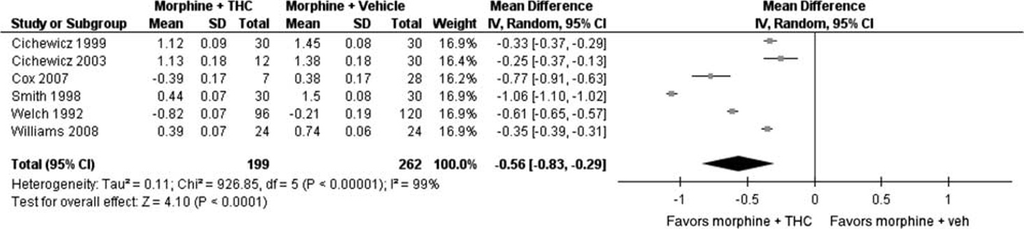

Figure 2

Forrest plot for meta-analysis examining the opioid-sparing effect of delta-9-THC when co-administered with morphine. Note: all mean difference

and SD values are of log10ED50. THC, tetrahydrocannabinol.

(MD in the log10ED50 –0.98 (–1.76, –0.21)). Significant

heterogeneity in the data (I<sup>2</sup>= 98%) necessitated the use of a

random effects model. When back-transformed to the

original units, the response ratio was 9.5 (95% CI 1.6,

57.5), indicating that the ED50 of codeine was 9.5 times lower

when given in combination with delta-9-THC compared to

when codeine was administered alone.

Funnel plots did not provide evidence of publication or

small study bias with these pre-clinical studies (Figure 4).

Results from Clinical Studies

Nine clinical studies with 750 participants provided data

relevant to the research question (Table 2); however, the

heterogeneous nature of the studies precluded meta-analysis.

Three laboratory-based studies examined pain responses in

participants concurrently being administered opioids and

cannabinoids. One study recruited people with mixed

chronic non-cancer pain (n = 24) who were prescribed

opioids (Abrams et al, 2011). A significant reduction in pain

ratings was observed for the participants in this study

following co-administration of cannabinoids—39.6 (95% CI

35.8, 43.3) at baseline vs 29.1 (95% CI 25.4, 32.8) following

co-administration (Abrams et al, 2011). It should be noted

that no placebo or control condition was used in this study

for comparison (Abrams et al, 2011).

In another two studies, healthy volunteers (n = 12 and 13,

respectively) participated in crossover studies, with single

doses of placebo, morphine alone, dronabinol alone, and

dronabinol and morphine combined administered over four

sessions (Naef et al, 2003; Roberts et al, 2006). These studies

did not identify a synergistic effect on experimental pain in

healthy controls, although Roberts et al (2006) found that the

co-administration of dronabinol and morphine resulted in a

reduced unpleasantness of pain compared to either drug

alone. In a case series examining the effects of cannabinoid

administration in patients with chronic non-cancer pain,

three patients with mixed pain conditions (multiple sclerosis,

HIV-related peripheral neuropathy, and lower back and leg

pain) reported reductions in opioid requirements after

initiation of smoked cannabis plant material (Lynch and

Clark, 2003).

Five controlled studies were identified. One small, non-

randomized study of patients with advanced cancer pain

found that 5 out of 12 patients achieved pain control

after receiving a cannabis infusion, compared with 2 out of

14 achieving pain control in the control group—a non-

statistically different effect (Lissoni et al, 2014). Two

randomized

controlled

trials

examined

delta-9-THC :

Cannabidiol

(THC : CBD)

combination

oral

sprays

compared to a placebo (Johnson et al, 2010; Portenoy et al,

2012) in patients with cancer pain who were taking opioids.

These studies found improved analgesia with the THC : CBD

combination compared to the placebo. Johnson et al (2010)

found no effect of THC : CBD on breakthrough opioid dose

requirements. Portenoy et al (2012) conducted a dose-

ranging study, using fixed dose ranges of the THC : CBD

combination. In this study, a significant analgesic effect was

only found in the lowest dose group, with poorer tolerability

observed for higher doses.

Two controlled studies examined the effects of dronabinol:

one in patients with mixed chronic pain (Narang et al, 2008)

and one in patients with prostate cancer (Seeling et al, 2006).

Narang et al (2008) found significantly reduced pain

intensity

with

the

opioid–cannabinoid

combination

in

double-blinded laboratory sessions compared to opioid

alone. Additional improvements in sleep, energy, and social

functioning were reported in a 4-week open-label phase of

the same study (Narang et al, 2008). In the study by Seeling

et al (2006), perioperative use of dronabinol compared with

a placebo in patients with prostate cancer, no difference

was found in self-administered opioid dose requirements

between groups.

Quality Ratings of Clinical Studies

The clinical studies were rated using the GRADE criteria.

One study provided very-low-quality evidence, three studies

provided

low-quality

evidence,

two

studies

provided

moderate-quality evidence, and three randomized controlled

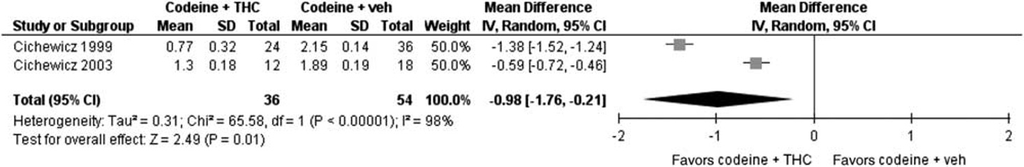

Figure 3

Forrest plot for meta-analysis examining the opioid-sparing effect of delta-9-THC when co-administered with codeine. Note: all mean difference

and SD values are of log10ED50. THC, tetrahydrocannabinol.

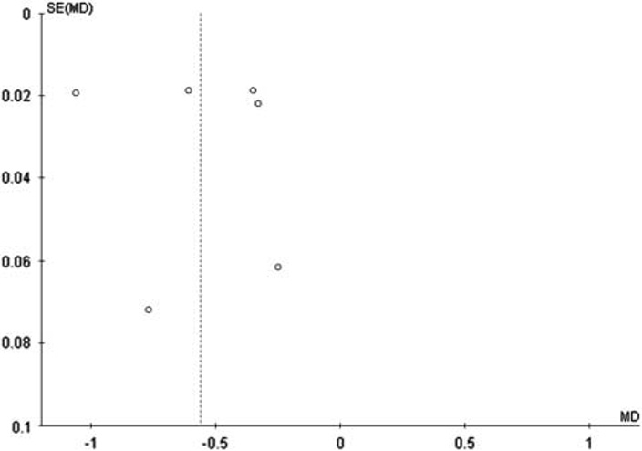

Figure 4

Funnel plot showing data from the six studies included in the

meta-analysis. MD, mean difference, SE, standard error.

Table 2 Summary of Evidence of Opioid-sparing Effects from Clinical Studies

(a) Study

reference

Study design

Population

Follow-up

period

Opioid used

Cannabinoid used

Effect of cannabinoid on

opioid dose

Outcome on analgesia

observed

GRADE evidence rating

and other notes

Laboratory studies

Abrams

et al, 2011

Clinical laboratory study of

self-reported pain under

observed conditions (also

measured pharmacokinetic

effects of concurrent

administration)

People (n = 24)

receiving chronic

opioid treatment

(mixed pain

conditions)

5 days

Morphine sulfate

(mean daily dose

62 mg, n = 13) or

oxycodone

hydrochloride (mean

daily dose 53 mg,

n = 11)

Vaporized cannabis dose

of 0.9 g of 3.56% delta-

9-THC or as much as

they could tolerate,

administered three times

per day.

Opioid dose held constant to

examine effect of delta-9-

THC on opioid

pharmacokinetics (ie, no

reduction from baseline

opioid dose possible).

Mean pain score reduction,

from 34.8 (95% CI 29.4, 40.1)

at baseline to 24.1 (95% CI

18.8, 29.4) on day 5 with

morphine, and from 43.8

(95% CI 38.6, 49.1) at baseline

to 33.6 (95% CI 28.5, 38.6) on

day 5 with oxycodone.

Significant reduction overall.

Cannabis inhalation

produced a subjective ‘high’.

GRADE rating ‘low’ quality.

Downgraded as study did

not have a placebo

condition, so placebo effects

cannot be excluded

Note: no pharmacokinetic

interaction observed.

Naef et al,

2003

Experimental heat, cold,

pressure, single and repeated

transcutaneous electrical

stimulation pain,

randomized, placebo-

controlled, double-blinded,

crossover study.

Healthy cannabis

naive volunteers

(n = 12)

Four study

sessions with at

least 7 days

washout

between sessions

Morphine (30 mg)

daily

Dronabinol (20 mg)

No significant analgesic effect

of dronabinol or morphine–

dronabinol combination on

heat, pressure, or cold tests.

Additive effect of morphine

on transcutaneous electrical

stimulation test.

Potentiation of analgesia not

observed in this experimental

pain study.

GRADE rating ‘moderate’.

Placebo-controlled, blinded

study. Downgraded due to

indirect evidence as use of

experimental pain measures.

Roberts

et al, 2006

Experimental thermal pain.

Double-blinded, four

treatment crossover design.

Healthy volunteers

(n = 13) with no

recent opioid or

cannabinoid use

Four lab sessions

Morphine (0.02 mg/kg

IV, 1.4 mg dose for

70 mg adult, ie, sub-

analgesic)

Dronabinol (5 mg)

NA (opioid dose held

constant)

Combination of delta-9-THC

and morphine did not have an

effect on pain intensity. The

combination resulted in lower

ratings of unpleasantness of

pain compared with either

drug alone.

GRADE rating ‘moderate’.

Placebo-controlled, blinded

study. Downgraded due to

indirect evidence as use of

experimental pain measures.

Case series

Lynch and

Clark,

2003

Observational case series

Mixed pain

conditions (n = 3)

(peripheral

neuropathy,

multiple sclerosis,

lower back pain)

1–9-month

observation

period

Morphine (75–360 mg

daily)

Smoked cannabis plant,

unknown content

Mean baseline morphine dose

of 195 mg (SD 147 mg)

compared with 35 mg (SD

31 mg) after commencing

smoked cannabis. Opioid

dose reduction or cessation in

each case.

Improved pain control

described, with patients either

reducing or ceasing morphine

dose.

GRADE rating ‘very low’.

(b) Study

reference

Study design

Population

Follow-up

period

Opioid used

Cannabinoid used

Effect of cannabinoid

on opioid dose

Outcome on analgesia

observed

GRADE evidence

rating and other notes

Controlled trials

Johnson

et al, 2010

Multicenter, double-

blind, randomized,

placebo-controlled,

parallel-group trial.

Patients with cancer pain

(n = 177), with inadequate

analgesia despite chronic

opioid dosing.

2 weeks

Varied opioids reported as

OME (IQR)

120 mg (50–213)

80 mg (30–180)

120 mg (40–240)

Patients randomized to

delta-9-THC : CBD,

delta-9-THC, or

placebo

Delta-9-THC (mean 9

sprays per day)

Delta-9-THC : CBD

(mean 10 sprays

per day)

Placebo

(mean 11 sprays/day)

No change in median

amount of breakthrough

opioid medication in any

group.

Change in pain NRS (out of

10) from baseline was

statistically significantly in

favor of delta-9-

THC : CBD compared with

the placebo

–1.01 (p = 0.245)

–1.37 (p = 0.014)

–0.69 (reference group)

GRADE rating ‘high’.

Placebo-controlled and

randomized.

Table 2 Continued

(b) Study

reference

Study design

Population

Follow-up

period

Opioid used

Cannabinoid used

Effect of cannabinoid

on opioid dose

Outcome on analgesia

observed

GRADE evidence

rating and other notes

Lissoni

et al, 2014

Two groups (not

randomized):

cannabinoid tincture or

melatonin

Patients with untreatable

metastatic solid tumor

(n = 26)

Not stated

Oxycodone, median dose

of 30 mg (10–60 mg),

twice per day

Cannabis flos (19%

delta-9-THC) was given

as an infusion. 100 ml

(500 mg/l water) three

times per day

5/12 patients (42%)

achieved control of pain

without opioid dose

increase compared to the

control group, where 2/14

(14%) achieved pain

control

The number that achieved

pain control was not

significantly different

between groups

GRADE rating ‘low’. Non-

randomized design, no

allocation concealment

described. Control group

received melatonin (20–

100 mg). Greater disease

progression documented

in the cannabis group

Narang

et al, 2008

Phase 1: randomized,

single-dose, double-

blinded, placebo-

controlled, crossover

trial. Primary outcome

measures TOTPAR

score

Patients on opioids for

chronic pain; BPI ⩾ 4

(n = 30). Pain diagnosis:

neuropathic (n = 7),

nociceptive (n = 7), mixed

neuropathic and

nociceptive (n = 11), and

uncategorized (n = 5)

Phase 1: three 8-h

lab sessions with

3 days washout

OME mean 68.1 mg (SD

57.2, range 7.5–228).

Participants were taking

oxycodone, morphine,

methadone hydrocodone,

and hydromorphone

Phase 1: single-dose

placebo, dronabinol 10

and 20 mg

One subject took rescue

pain medication in all

conditions, one subject

took rescue medication

during the placebo and

10 mg dronabinol

condition, and six subjects

took rescue medication

only with placebo.

In single-dose studies, 10

and 20 mg dronabinol

significantly increased the

amount of analgesic relief

reported compared to

placebo

GRADE rating ‘moderate’.

Randomized and placebo-

controlled. Downgraded as

only a single dose was

examined. TOTPAR 31.1

in placebo group,

compared with 39.7 with

dronabinol 10 mg and 41.7

with dronabinol 20 mg

Phase 2: open-label (no

placebo) extension.

Primary outcome

measure change in pain

intensity

Phase 2: open

label for 4 weeks

Phase 2: flexible dose

schedule, dronabinol

5 mg daily – 20 mg

three times per day.

Opioid dose not reported

Mean baseline NRS of 6.9

compared with 5.2 after

4 weeks of dronabinol. This

represents a statistically

significant reduction

GRADE rating ‘low’. Open-

label study. Significant

improvements (po0.05) in

sleep, energy, pain relief,

and social functioning. Lack

of placebo control means

effects may be non-specific

or placebo

Portenoy

et al, 2012

Randomized, 4-arm

placebo-controlled,

graded-dose study

Patients with active cancer

and chronic pain on a

stable oral morphine

regimen, plus fentanyl

(n = 360)

5 weeks of

medication

administration

Morphine and fentanyl

Median 120 mg OME

Median 120 mg OME

Median 180 mg OME

Median 120 mg OME

Nabiximols 1–4 sprays

Nabiximols 6–10 sprays

Nabiximols 11–16

sprays

Placebo

No change in median

amount of breakthrough

opioid medication in any

group. Note that patients

were discouraged from

reducing their opioid dose,

so the opioid-sparing effect

could not be observed

Treatment difference

(change from baseline pain

score):

–0.75 points (95% CI–1.28,

to placebo)

–0.36 points (95% CI –.089,

0.18 points, p = 0.19

compared to placebo).

–0.09 points (95% CI: –

0.62, 0.44 points, p = 0.75

compared to placebo)

Not reported

(reference group)

GRADE rating ‘high’.

Placebo-controlled,

randomized controlled trial

Opioid composite

measure showed better

improvements in the low-

dose group. 1–4 spray

group had significant

improvements in analgesia.

Lower tolerability of delta-

9-THC : CBD in higher

dose groups

Seeling

et al, 2006

Randomized,

controlled trial (two

groups)

Prostate cancer patients

o70 y.o. (n = 105).

N = 53 in intervention and

52 in control

From the day prior

to surgery to two

days post

operation

Piritramide 1.5 mg/ml,

bolus 2 mg (no continuous

infusion) via patient-

controlled analgesia for

48 h post operation

Dronabinol 5 mg × 8

doses over 48 h

(perioperatively)

Median dose of piritramide

alone was 74 mg (IQR 44–

90) compared with 54 mg

(IQR 46–88) when

administered with

dronabinol

The difference between the

intervention (dronabinol)

group and control group

was not significant. No

evidence was found of

synergistic antinociceptive

interaction between delta-

9-THC and piritramide for

acute postoperative pain

GRADE rating ‘high’.

Placebo-controlled,

randomized controlled trial

Patients administered their

own opioid doses

Abbreviations: BPI, brief pain inventory; CBD, cannabidiol; GRADE, Grading of Recommendations Assessment, Development and Evaluation; IQR, interquartile range; NRS, numerical rating scale; OME, oral morphine

equivalents; TOTPAR, total pain relief.

trials provided high-quality evidence. None of the high-

quality studies provided evidence of an opioid-sparing effect.

The only study that provided direct evidence of an opioid-

sparing effect was rated as providing very low-quality

evidence (Lynch and Clark, 2003).

DISCUSSION

Twenty-eight studies provided data relating to the potential

opioid-sparing effect of cannabinoids in the context of opioid

analgesia. Most of the pre-clinical studies examined reported

reduced opioid requirements when co-administered with

cannabinoids. Few controlled clinical studies measured

opioid-sparing as an end point and findings relating to

analgesia were mixed. Two controlled studies found no effect

of cannabinoids on opioid dose requirements (Johnson et al,

2010; Seeling et al, 2006). One case series provided very

low-quality evidence of a reduction in opioid dose require-

ments with cannabinoid co-administration (Lynch and

Clark, 2003).

Most of the pre-clinical studies examined found synergistic

effects when opioids and cannabinoids were co-adminis-

tered, although two studies found that with specific opioids

and cannabinoids the analgesic effect was additive rather

than synergistic. Through meta-analyses, it was found that

the doses of morphine and codeine required to produce the

same

analgesic

effect

were

3.6

and

9.5 times

lower,

respectively, when co-administered with delta-9-THC. Re-

ductions in opioid requirements that are smaller than those

seen in these pre-clinical studies may have relevance to pain

treatment. Some confidence in these findings comes from the

consistent observation of an opioid-sparing effect when

using different nociceptive assays and in pain models of

arthritis and diabetic neuropathy.

The relevance of the findings from these pre-clinical

studies (with acute-dosing paradigms) to clinical chronic

pain treatment must be considered. There are important

limitations in translating findings from pre-clinical studies to

clinical practice, particularly when evaluating doses and

effect sizes. Although the outcomes of pre-clinical studies are

often consistent with clinical studies, pre-clinical studies may

over-represent effects. The lesser effect sizes in human

studies have been attributed to the heterogeneity of clinical

populations or the response being limited to sub-popula-

tions, reducing the overall effect observed (Berge, 2011). This

underscores the importance of clinical studies to examine the

effects found in pre-clinical work.

Controlled clinical studies demonstrated some beneficial

effects of opioid and cannabinoid co-administration on

outcomes of pain, sleep, and functioning in chronic pain

patients (Abrams et al, 2011; Narang et al, 2008). One case

series (n = 3) provided very low-quality evidence of a

reduction in opioid requirements with delta-9-THC admin-

istration. No randomized controlled studies were identified

that provided evidence of an opioid-sparing effect of

cannabinoids. Important limitations identified in these

clinical studies included a lack of placebo control (Abrams

et al, 2011; Lynch and Clark, 2003; Narang et al, 2008),

difficulties

extrapolating

from

experimental

to

clinical

pain (Naef et al, 2003; Roberts et al, 2006), use of single

doses (Naef et al, 2003; Roberts et al, 2006), use of small

sample sizes (Lissoni et al, 2014; Lynch and Clark, 2003;

Narang et al, 2008), and the mixed quality of the study

design in general. In particular, Roberts et al (2006) used

sub-therapeutic doses of morphine, which may have limited

that study’s ability to test the effects of co-administration.

Portenoy et al (2012) noted that the use of fixed dose ranges

of cannabinoids may have limited that study’s ability to test

the efficacy of cannabinoids for pain, as some patients may

have

dropped

out

due

to

tolerability.

Moreover,

by

discouraging patients from reducing their opioid dose during

the study, no opioid-sparing effect could be observed

(Portenoy et al, 2012).

This review highlights some important considerations for

future studies of cannabinoids. A dose-ranging study with

patients with advanced cancer found that only lower doses of

cannabinoids demonstrated analgesic effects (Portenoy et al,

2012). In the same study, one in four participants in the

high-dose group discontinued treatment. Side effects such as

nausea, drowsiness, and dizziness are more frequent with

higher doses of cannabinoids (Narang et al, 2008; Portenoy

et al, 2012). This suggests that dose range and tolerability are

important outcomes to examine and that careful dose

titration is essential. Future studies should carefully docu-

ment adverse effects from concurrent opioid and cannabi-

noid administration to provide a better understanding of

potential harms. One hypothesis to explain why patients

reduce their opioid dose with cannabinoid administration is

that they experience undesirable psychoactive effects from

concurrent use of opioids and cannabinoids. This could be

explored in future studies.

Recent observational studies provided further data on a

possible opioid-sparing effect. Two studies found 44–64%

reductions in self-reported opioid consumption in cohorts of

patients with chronic pain who were using cannabis

(Boehnke et al, 2016; Haroutounian et al, 2016). These

observational studies provide further low-quality evidence

supporting an opioid-sparing effect. A further observational

study found that in patients with chronic pain who were

prescribed opioids, greater pain relief was reported from

cannabis than from their other medications (Degenhardt

et al, 2015). A single case study also reported reduced

requirements for breakthrough pain with oral delta-9-THC

administration (Holdcroft et al, 1997). Taken together, these

reports support the need for high-quality studies to directly

assess the opioid-sparing effect of cannabinoids under

controlled conditions.

This review identified some limitations in the literature.

The pre-clinical studies examined used a range of animal

populations, antinociceptive assays, opioids, and cannabi-

noids, and often had small numbers of animals per group.

This resulted in statistical heterogeneity. Despite this, a large

and significant effect was observed in the meta-analysis. No

studies examined the opioid-sparing effect of cannabidiol

alone, in combination with delta-9-THC outside of a 1 : 1

ratio, or with other cannabinoids. Further, the lack of high-

quality studies in humans investigating the opioid-sparing

effect means that the evidence for this is largely limited

to pre-clinical studies. A funnel plot was produced and did

not provide evidence of publication or small study bias;

however, due to the small number of studies in the meta-

analysis (o10) the interpretation of the funnel plot is

limited.

The potential for cannabinoids to reduce opioid dose

requirements and extend the duration of effective analgesia

should not be understated. The rapid increase in opioid use

and opioid-associated mortality is largely attributed use

of opioids in chronic pain treatment (Chou et al, 2015;

Zedler et al, 2014). Use of lower opioid doses has been

recommended (Dowell et al, 2016); however, clinical processes

to achieve this reduction are not well defined. Opioid-sparing

medications

may

have

enormous

clinical relevance

by

enabling effective pain treatment with lower opioid doses

and a potential reduction in opioid-related mortality.

In conclusion, pre-clinical studies support the opioid-

sparing effect of delta-9-THC. However, the findings from

clinical trials are inconsistent, with some studies found to

have important limitations such as a lack of placebo control.

An opioid-sparing effect of cannabinoids in chronic pain

patients was observed in only one very-low-quality clinical

study. These findings provide an early signal that warrants

exploration. It remains to be seen if these promising pre-

clinical and observational findings can be replicated in large,

well-designed clinical studies.

FUNDING AND DISCLOSURE

SN

is

supported

by

a

NHMRC

Research

Fellowship

(#1013803). The National Drug and Alcohol Research Centre

at the University of New South Wales is supported by

funding

from

the

Australian

Government

under

the

Substance Misuse Prevention and Service Improvements

Grant Fund. The contents of the published material are solely

the responsibility of the authors and do not reflect the

funding bodies. MAW has received a grant to his institution

from CanniMed. BLF has received speaker fees or consulting

fees from Allergan, Mettrum, CCIC, Mylan Pharmaceutical,

Pfizer, Ethypharm, Richter Pharmaceuticals, and Lundbeck.

He also received salary/grant support from Pfizer and

Bioprojet, and in kind support from GW Pharma, Mylan

Pharmaceuticals, and Brainsway. SN and NL have been

investigators on untied educational grants from Reckitt-

Benckiser. SN and MF have been investigators on an untied

education grant from Indivior. KEK has previously received

a speaker’s honorarium from Pfizer and Mundipharma, in

addition to fees from an advisory board and an educational

grant from Seqirus. As Director of NDARC, MF notes that

the National Drug and Alcohol Research Centre has received

untied educational grants from Mundipharma and Indivior.

MF took part in a single research advisory board with

Indivior in 2014. The remaining authors declare no conflict

of interest.

ACKNOWLEDGMENTS

SN, PS, JMT, MAW, BM, NL, KEK, MF, AS, and BLF were

involved in the conceptualization of the work. SN and PS

screened the abstracts. SN, PS, and JMT extracted the data

and checked the extracted data. BBS transformed the data,

prepared the data for meta-analysis, and provided advice on

the meta-analysis. SN conducted the meta-analysis and

drafted the manuscript with assistance from BM, PS, and

JMT. All authors revised the manuscript and approved the

final version.

REFERENCES

Abrams DI, Couey P, Shade SB, Kelly ME, Benowitz NL (2011).

Cannabinoid-opioid interaction in chronic pain. Clin Pharmacol

Ther 90: 844–851.

Berge O-G (2011). Predictive validity of behavioural animal models

for chronic pain. Br J Pharmacol 164: 1195–1206.

Boehnke KF, Litinas E, Clauw DJ (2016). Medical cannabis use is

associated with decreased opiate medication use in a retrospective

cross-sectional survey of patients with chronic pain. J Pain 17:

739–744.

Cencioni MT, Chiurchiu V, Catanzaro G, Borsellino G, Bernardi G,

Battistini L et al (2010). Anandamide suppresses proliferation and

cytokine release from primary human T-lymphocytes mainly via

CB2 receptors. PLoS ONE 5: e8688.

Chou R, Turner JA, Devine EB, Hansen RN, Sullivan SD, Blazina I

et al (2015). The effectiveness and risks of long-term opioid

therapy for chronic pain: a systematic review for a National

Institutes of Health Pathways to Prevention Workshop Effective-

ness and Risks of Long-Term Opioid Therapy for Chronic Pain.

Ann Intern Med 162: 276–286.

Cichewicz DL (2004). Synergistic interactions between cannabinoid

and opioid analgesics. Life Sci 74: 1317–1324.

Cichewicz DL, Martin ZL, Smith FL, Welch SP (1999). Enhance-

ment mu opioid antinociception by oral delta9-tetrahydrocanna-

binol:

dose-response

analysis

and

receptor

identification.

J Pharmacol Exp Ther 289: 859–867.

Cichewicz DL, McCarthy EA (2003). Antinociceptive synergy

between delta(9)-tetrahydrocannabinol and opioids after oral

administration. J Pharmacol Exp Ther 304: 1010–1015.

Cichewicz DL, Welch SP (2003). Modulation of oral morphine

antinociceptive tolerance and naloxone-precipitated withdrawal

signs by oral Delta 9-tetrahydrocannabinol. J Pharmacol Exp Ther

305: 812–817.

Cichewicz DL, Welch SP, Smith FL (2005). Enhancement of

transdermal fentanyl and buprenorphine antinociception by trans-

dermal delta9-tetrahydrocannabinol. Eur J Pharmacol 525: 74–82.

Cox ML, Haller VL, Welch SP (2007). Synergy between delta9-

tetrahydrocannabinol and morphine in the arthritic rat. Eur J

Pharmacol 567: 125–130.

da Fonseca Pacheco D, Klein A, de Castro Perez A, da Fonseca

Pacheco CM, de Francischi JN, Duarte ID (2008). The mu-opioid

receptor agonist morphine, but not agonists at delta- or kappa-

opioid receptors, induces peripheral antinociception mediated by

cannabinoid receptors. Br J Pharmacol 154: 1143–1149.

Degenhardt L, Lintzeris N, Campbell G, Bruno R, Cohen M,

Farrell M et al (2015). Experience of adjunctive cannabis use for

chronic non-cancer pain: findings from the Pain and Opioids IN

Treatment (POINT) study. Drug Alcohol Depend 147: 144–150.

Dowell D, Haegerich TM, Chou R (2016). CDC Guideline for

Prescribing Opioids for Chronic Pain - United States, 2016.

MMWR Recomm Rep 65: 1–49.

Finn DP, Beckett SR, Roe CH, Madjd A, Fone KC, Kendall DA et al

(2004). Effects of coadministration of cannabinoids and mor-

phine on nociceptive behaviour, brain monoamines and HPA

axis activity in a rat model of persistent pain. Eur J Neurosci 19:

678–686.

Gui H, Tong Q, Qu W, Mao CM, Dai SM (2015). The

endocannabinoid system and its therapeutic implications in

rheumatoid arthritis. Int Immunopharmacol 26: 86–91.

Guyatt GH, Oxman AD, Vist GE, Kunz R, Falck-Ytter Y,

Alonso-Coello P et al (2008). GRADE: an emerging consensus

on rating quality of evidence and strength of recommendations.

Br Med J 336: 924–926.

Haroutounian S, Ratz Y, Ginosar Y, Furmanov K, Saifi F, Meidan R

et al (2016). The effect of medicinal cannabis on pain and quality

of life outcomes in chronic pain: a Prospective Open-label Study.

Clin J Pain 32: 1036–1043.

Herkenham M, Lynn AB, Johnson MR, Melvin LS, de Costa BR,

Rice KC (1991). Characterization and localization of cannabinoid

receptors

in

rat brain:

a quantitative

in

vitro

autoradio-

graphic study. J Neurosci 11: 563–583.

Hohmann AG, Briley EM, Herkenham M (1999). Pre- and

postsynaptic distribution of cannabinoid and mu opioid receptors

in rat spinal cord. Brain Res 822: 17–25.

Holdcroft A, Smith M, Jacklin A, Hodgson H, Smith B, Newton M

et al (1997). Pain relief with oral cannabinoids in familial

Mediterranean fever. Anaesthesia 52: 483–486.

Houser SJ, Eads M, Embrey JP, Welch SP (2000). Dynorphin B and

spinal analgesia: induction of antinociception by the cannabi-

noids CP55,940, Delta(9)-THC and anandamide. Brain Res 857:

337–342.

Howlett AC, Barth F, Bonner TI, Cabral G, Casellas P, Devane WA

et al (2002). International Union of Pharmacology. XXVII. Classi-

fication of cannabinoid receptors. Pharmacol Rev 54: 161–202.

Ibrahim M, Rude M, Stagg N, Mata H, Lai J, Vanderah T et al

(2006). CB2 cannabinoid receptor mediation of antinociception.

Pain 122: 36–42.

Ibrahim MM, Porreca F, Lai J, Albrecht PJ, Rice FL, Khodorova A

et al (2005). CB2 cannabinoid receptor activation produces

antinociception by stimulating peripheral release of endogenous

opioids. Proc Natl Acad Sci USA 102: 3093–3098.

Jensen B, Chen J, Furnish T, Wallace M (2015). Medical marijuana

and chronic pain: a review of basic science and clinical evidence.

Curr Pain Headache Rep 19: 50.

Johnson JR, Burnell-Nugent M, Lossignol D, Ganae-Motan ED,

Potts R, Fallon MT (2010). Multicenter, double-blind, rando-

mized, placebo-controlled, parallel-group study of the efficacy,

safety, and tolerability of THC:CBD extract and THC extract in

patients with intractable cancer-related pain. J Pain Symptom

Manage 39: 167–179.

Katsuyama S, Mizoguchi H, Kuwahata H, Komatsu T, Nagaoka K,

Nakamura H et al (2013). Involvement of peripheral cannabinoid

and opioid receptors in beta-caryophyllene-induced antinocicep-

tion. Eur J Pain 17: 664–675.

Li JX, McMahon LR, Gerak LR, Becker GL, France CP (2008).

Interactions between Delta(9)-tetrahydrocannabinol and mu

opioid receptor agonists in rhesus monkeys: discrimination and

antinociception. Psychopharmacology 199: 199–208.

Lissoni P, Porro G, Messina G, Porta E, Rovelli F, Roselli MG et al

(2014). Morphine, melatonin, Marijuana, Magnolia and MYRRH

as the "five m" schedule in the treatment of cancer pain

and the possible dose-dependency of the antitumor and analgesic

effects of the pineal hormone melatonin. Anticancer Res 34:

6033–6034.

Litchfield JA, Wilcoxon F (1949). A simplified method of evaluating

dose-effect experiments. J Pharmacol Exp Ther 96: 99–113.

Lynch ME, Clark AJ (2003). Cannabis reduces opioid dose in the

treatment of chronic non-cancer pain. J Pain Symptom Manage

25: 496–498.

Maguire DR, Yang W, France CP (2013). Interactions between mu-

opioid receptor agonists and cannabinoid receptor agonists in

rhesus monkeys: antinociception, drug discrimination, and drug

self-administration.(Erratum appears in J Pharmacol Exp Ther.

2014 Mar; 348(3): 490-1 Note: Dosage error in article text).

J Pharmacol Exp Ther 345: 354–362.

Manzanares J, Corchero J, Romero J, Fernandez-Ruiz JJ, Ramos JA,

Fuentes JA (1999). Pharmacological and biochemical interactions

between opioids and cannabinoids. Trends Pharmacol Sci 20:

287–294.

Mason DJ Jr, Lowe J, Welch SP (1999). Cannabinoid modulation of

dynorphin A: correlation to cannabinoid-induced antinocicep-

tion. Eur J Pharmacol 378: 237–248.

Moher D, Liberati A, Tetzlaff J, Altman DG (2009). Preferred

reporting items for systematic reviews and meta-analyses: the

PRISMA statement. PLoS Med 6: e1000097.

Naef

M,

Curatolo

M,

Petersen-Felix

S,

Arendt-Nielsen

Zbinden A, Brenneisen R (2003). The analgesic effect of<sup>L,</sup>

oral

delta-9-tetrahydrocannabinol

(THC), morphine,

and

THC-morphine combination in healthy subjects under experi-<sup>a</sup>

mental pain conditions. Pain 105: 79–88.

Narang

S,

Gibson

D,

Wasan

AD,

Ross

EL,

Michna

E,

Nedeljkovic SS et al (2008). Efficacy of dronabinol as an adjuvant

treatment for chronic pain patients on opioid therapy. J Pain 9:

254–264.

Pertwee RG (2006). The pharmacology of cannabinoid receptors

and their ligands: an overview. Int J Obes 30: S13–S18.

Pertwee RG (2008). The diverse CB1 and CB2 receptor pharmacol-

ogy of three plant cannabinoids: delta9-tetrahydrocannabinol,

cannabidiol and delta9-tetrahydrocannabivarin. Br J Pharmacol

153: 199–215.

Portenoy

RK,

Ganae-Motan

ED,

Allende

S,

Yanagihara

R,

Shaiova L, Weinstein S et al (2012). Nabiximols for opioid-

treated cancer patients with poorly-controlled chronic pain: a

randomized, placebo-controlled, graded-dose trial. J Pain 13:

438–449.

Pugh G Jr, Mason DJ Jr, Combs V, Welch SP (1997). Involvement

of

dynorphin

B

in

the

antinociceptive

effects

of

the

cannabinoid CP55,940 in the spinal cord. J Pharmacol Exp Ther

281: 730–737.

Pugh G Jr, Smith PB, Dombrowski DS, Welch SP (1996). The role of

endogenous opioids in enhancing the antinociception produced

by

the

combination

of

DELTA9-tetrahydrocannabinol

and

morphine in the spinal cord. J Pharmacol Exp Ther 279:

608–616.

Quartilho A, Mata HP, Ibrahim MM, Vanderah TW, Porreca F,

Makriyannis

A

et

al

(2003).

Inhibition

of

inflammatory

hyperalgesia

by

activation

of

peripheral

CB2

cannabinoid

receptors. Anesthesiology 99: 955–960.

Reche I, Fuentes JA, Ruiz-Gayo M (1996). Potentiation of delta

9-tetrahydrocannabinol-induced analgesia by morphine in mice:

involvement of mu- and kappa-opioid receptors. Eur J Pharmacol

318: 11–16.

Rice AS, Smith BH, Blyth FM (2015). Pain and the global burden of

disease. Pain 157: 791–796.

Roberts JD, Gennings C, Shih M (2006). Synergistic affective

analgesic interaction between delta-9- tetrahydrocannabinol and

morphine. Eur J Pharmacol 530: 54–58.

Salio C, Fischer J, Franzoni MF, Mackie K, Kaneko T, Conrath M

(2001). CB1-cannabinoid and mu-opioid receptor co-localization

on postsynaptic target in the rat dorsal horn. NeuroReport 12:

3689–3692.

Seeling W, Kneer L, Buchele B, Gschwend J, Maier L, Nett C et al

(2006). DELTA9-tetrahydrocannabinol and the opioid receptor

agonist piritramide do not act synergistically in postoperative

pain. Anaesthesist 55: 391–400.

Smith

FL,

Cichewicz

D,

Martin

ZL,

Welch

SP

(1998).

The enhancement of morphine antinociception in mice by

delta9-tetrahydrocannabinol.

Pharmacol

Biochem

Behav

60:

559–566.

Smith PA, Selley DE, Sim-Selley LJ, Welch SP (2007). Low dose

combination

of

morphine

and

delta9-tetrahydrocannabinol

circumvents antinociceptive tolerance and apparent desensitiza-

tion of receptors. Eur J Pharmacol 571: 129–137.

Smith PB, Welch SP, Martin BR (1994). Interactions between delta

9-tetrahydrocannabinol and kappa opioids in mice. J Pharmacol

Exp Ther 268: 1381–1387.

Tham SM, Angus JA, Tudor EM, Wright CE (2005). Synergistic and

additive interactions of the cannabinoid agonist CP55,940 with

mu opioid receptor and alpha2-adrenoceptor agonists in acute

pain models in mice. Br J Pharmacol 144: 875–884.

Valverde O, Noble F, Beslot F, Dauge V, Fournie-Zaluski MC,

Roques BP (2001). Delta9-tetrahydrocannabinol releases and

facilitates the effects of endogenous enkephalins: reduction in

morphine withdrawal syndrome without change in rewarding

effect. Eur J Neurosci 13: 1816–1824.

Vigano D, Rubino T, Parolaro D (2005). Molecular and cellular

basis of cannabinoid and opioid interactions. Pharmacol Biochem

Behav 81: 360–368.

Volkow ND, McLellan AT (2016). Opioid abuse in chronic pain —

misconceptions and mitigation strategies. N Engl J Med 374:

1253–1263.

Wakley AA, Craft RM

(2011). THC-methadone and THC-

naltrexone interactions on discrimination, antinociception, and

locomotion in rats. Behav Pharmacol 22: 489–497.

Walker JM, Hohmann AG, Martin WJ, Strangman NM, Huang SM,

Tsou K (1999). The neurobiology of cannabinoid analgesia.

Life Sci 65: 665–673.

Walker JM, Huang SM (2002). Cannabinoid analgesia. Pharmacol

Ther 95: 127–135.

Ware MA, Fitzcharles M-A, Joseph L, Shir Y (2010a). The effects of

nabilone on sleep in fibromyalgia: results of a randomized

controlled trial. Anesth Analg 110: 604–610.

Ware MA, Wang T, Shapiro S, Robinson A, Ducruet T, Huynh T

et al (2010b). Smoked cannabis for chronic neuropathic pain: a

randomized controlled trial. CMAJ 182: E694–E701.

Welch

SP,

Stevens

DL

(1992).

Antinociceptive

activity

of

intrathecally

administered

cannabinoids

alone,

and

in

combination with morphine, in mice. J Pharmacol Exp Ther 262:

10–18.

Williams IJ, Edwards S, Rubo A, Haller VL, Stevens DL, Welch SP

(2006). Time course of

the enhancement and restoration

of

the

analgesic

efficacy

of

codeine

and

morphine

by

δ9-tetrahydrocannabinol. Eur J Pharmacol 539: 57–63.

Williams J, Haller VL, Stevens DL, Welch SP (2008). Decreased

basal endogenous opioid levels in diabetic rodents: effects on

morphine and delta-9-tetrahydrocannabinoid-induced antinoci-

ception. Eur J Pharmacol 584: 78–86.

Wilson AR, Maher L, Morgan MM (2008). Repeated cannabinoid

injections

into

the

rat

periaqueductal

gray

enhance

subsequent morphine antinociception. Neuropharmacology 55:

1219–1225.

Woodhams SG, Sagar DR, Burston JJ, Chapman V (2015). The role

of the endocannabinoid system in pain. Handb Exp Pharmacol

227: 119–143.

Yesilyurt O, Dogrul A, Gul H, Seyrek M, Kusmez O, Ozkan Y et al

(2003). Topical cannabinoid enhances topical morphine anti-

nociception. Pain 105: 303–308.

Zedler B, Xie L, Wang L, Joyce A, Vick C, Kariburyo F et al (2014).

Risk factors for serious prescription opioid-related toxicity or

overdose among veterans health administration patients. Pain

Med 15: 1911–1929.

Supplementary Information accompanies the paper on the Neuropsychopharmacology website (http://www.nature.com/npp)